# Introduction to Machine Learning

Vincenzo Lagani

October 23, 2017

### Data analysis task: predicting hand-written digits.

The present document shows how to use the multilayer perceptron and decision trees for building mathematical models able to automatically identify hand written digits.

### Set-up

We will use the *rpart* and *mxnet* packages for running the analysis. Let’s install and load them both.

```r
#installing package rpart
if(!require('rpart')){
  install.packages('rpart')
  library('rpart')
}

#installing package mxnet
if(!require('mxnet')){
  cran <- getOption("repos")
  cran["dmlc"] <- "https://apache-mxnet.s3-accelerate.dualstack.amazonaws.com/R/CRAN/"
  options(repos = cran)
  install.packages("mxnet")
  library("mxnet")
}

#additional packages for visualization purposes
if(!require('rpart.plot')){
  install.packages('rpart.plot')
  library('rpart.plot')
}
if(!require('corrplot')){
  install.packages('corrplot')
  library('corrplot')
}
```

### The data: the MNIST dataset.

The MNIST dataset is a collection of hand-written digits appositely created for testing machine learning methods. The dataset was originally provided by Chris Burges, Corinna Cortes and Yann LeCun (http://yann.lecun.com/exdb/mnist/). A CSV version for ease to load in R can be found here: https://pjreddie.com/projects/mnist-in-csv/, courtesy of Joseph Redmond. Donwload both training and test set and unzip them in the same folder containing this Rmd file.

Once the files are ready, they can be loaded in R:

```r
#loading training set
training <- read.csv('mnist_train.csv', header = FALSE, stringsAsFactors = FALSE);
training <- as.matrix(training);

#loading the test set
test <- read.csv('mnist_test.csv', header = FALSE, stringsAsFactors = FALSE);
test <- as.matrix(test);

#adding colnames
colnames(training) <- c('label', paste0('pixel', 1:(dim(training)[2] - 1)))
colnames(test) <- c('label', paste0('pixel', 1:(dim(test)[2] - 1)))
```

Let’s have a look to the sample number 50 of the training set:

```r
cat(training[50, ])
```

```
## 3 0 0 0 0 0 0 0 0 0 0 0 0 0 0 0 0 0 0 0 0 0 0 0 0 0 0 0 0 0 0 0 0 0 0 0 0 0 0 0 0 0 0 0 0 0 0 0 0 0 0 0 0 0 0 0 0 0 0 0 0 0 0 0 0 0 0 0 0 0 0 0 0 0 0 0 0 0 0 0 0 0 0 0 0 0 0 0 0 0 0 0 0 0 0 0 0 0 0 0 0 0 0 0 0 0 0 0 0 0 0 0 0 0 0 0 0 0 0 0 0 0 0 0 0 0 0 0 0 0 0 0 0 0 0 0 0 0 0 0 0 0 0 0 0 0 0 0 0…
```

The first ‘3’ indicates that the sample refers to the digit three; the rest of the values are a single-dimension representation of the following 28x28 pixels image, obtained by lining up the pixels by row:

[figure not shown]

```r
corrplot(t(matrix(training[50, -1], 28, 28)), method = 'shade',
         is.corr = FALSE, tl.pos = 'n', cl.pos = 'n')
```

### First attempt with neural networks

We will now attempt a very initial analysis with the multilayer perceptron implemented in mxnet.

```r
#setting mx seed for ensuring replication
mx.set.seed(12345)

#training the network
nn <- mx.mlp(data = training[ , -1], #training data
             label = training[ , 1], #training label
             array.layout = "rowmajor", #simply indicates that rows are samples
             hidden_node = c(5), #only one hidden layer with 5 nodes
             out_node = 10, #10 output nodes, one for each digit in 0-9
             activation = "tanh", #activation function for the hidden nodes
             out_activation = "softmax", #activation function for the output nodes
             learning.rate = 0.1, #learning rates
             num.round = 10, #number of rounds of the back-propagation algorithsm
             verbose = FALSE) #no display of additional information
```

The *nn* object now contains the topology and parameters of the network. We can use *nn* for predicting the label of the test set. Each prediction will have 10 values, one for each digit. In order to identify the predicted digit, we must find the maximum for each column

```r
#extracting predictions
predMatrix <- predict(nn, test[ , -1], array.layout = "rowmajor")
print(predMatrix[1:10, 1:5])
```

```
##              [,1]         [,2]         [,3]         [,4]        [,5]
##  [1,] 0.001983861 0.0108011588 4.179971e-05 0.2935396135 0.006479559
##  [2,] 0.017869947 0.0440004393 8.822457e-01 0.0005103276 0.003046454
##  [3,] 0.002333377 0.6309965253 6.283246e-03 0.1341794878 0.019457918
##  [4,] 0.035055317 0.0350443795 1.816841e-02 0.0387180559 0.003695614
##  [5,] 0.041602865 0.0093772225 6.279277e-03 0.0355750918 0.453267932
##  [6,] 0.022082770 0.0249495003 2.376273e-03 0.1327631027 0.010897131
##  [7,] 0.001402425 0.1354319751 4.049789e-04 0.2685510218 0.044080582
##  [8,] 0.655588031 0.0002995916 4.591241e-02 0.0024495632 0.077862419
##  [9,] 0.031973179 0.1068747044 2.729508e-02 0.0716860667 0.009675560
## [10,] 0.190108314 0.0022244409 1.099290e-02 0.0220276508 0.371536762
```

```r
#formatting predictions
preds <- apply(predMatrix, 2, which.max) - 1
print(preds[1:5])
```

```
## [1] 7 2 1 0 4
```

Finally, we can compute the accuracy of our predictions. We will also compute and display the confusion matrix, which represent the interplay between the actual label and the predicted ones.

```r
#accuracy
acc <- sum(preds == test[ , 1])/(dim(test)[1])
print(paste0('The accuracy is: ', round(acc, 3)))
```

```
## [1] "The accuracy is: 0.467"
```

```r
#confusion matrix
labels <- test[ , 1];
confusion <- table(preds, labels);
print('Confusion matrix')
```

```
## [1] "Confusion matrix"
```

```r
print(confusion)
```

```
##      labels
## preds   0   1   2   3   4   5   6   7   8   9
##     0 959  12 416 161  78 376 865  28 326  54
##     1   0 889  14   2  31   4   3  49  10   7
##     2   1  95 498  92   0  28  29  12  82   0
##     3  19  18  16 593   0 427   0  25 348  17
##     4   0   4  39  13 839  27  59 133  34 694
##     6   0   0   0   0   0   0   0   0   1   0
##     7   0  22   4  42  34  13   0 779  59 237
##     8   1  95  45 107   0  17   2   2 114   0
```

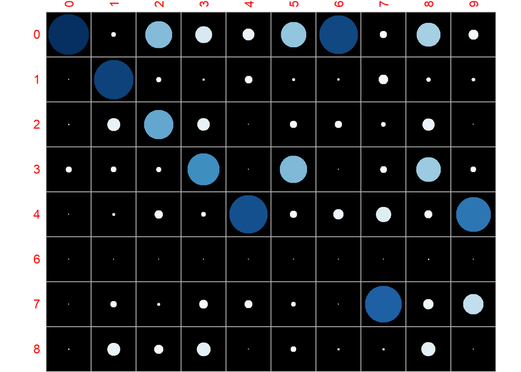

```r
corrplot(corr = confusion, method = 'circle', is.corr = FALSE, bg = 'black', cl.pos = 'n')
```

### What went wrong?

Obviously, our analysis gave poor results. The reasons can be several: too few back-propagation rounds, a slow learning rate, an insufficient number of hidden nodes. We will concentrate on the latter, by trying several *model configuration*. Each configuration will be identical to the others, except for the number of nodes in the hidden layer.

#### Experimentation protocol: training - validation - test

We will adopt a simple protocol for selecting the best configuration and assessing its performances:

- the models will be derive from the training set
- each model will be assessed on a validation set
- the configuration that best performs on the validation set will be used for training a final model on training + validation set combined
- the final model is assessed on the test set

The golden rule is that the test set is never used during the training of the models or the selection of the best configuration. Furthermore, only the performances obtained on the test set should be regarded as a reliable estimate of the predictive power of the model.

```r
#splitting the training set
set.seed(12345)
trainID <- sample(dim(training)[1], floor(0.8 * dim(training)[1]));
train <- training[trainID, ];
valid <- training[-trainID, ];
```

We can now loop over several configurations for identifying the best one.

```r
#number of nodes
ns <- c(4, 9, 16, 25, 36, 49)

#networks
nns <- vector('list', length(ns))

#accuracy vectors
trainAcc <- vector('numeric', length(ns))
validAcc <- vector('numeric', length(ns))

#setting mx seed
mx.set.seed(12345)

#looping over the  configurations
for(i in 1:length(ns)){

  #current cycle
  print(i)

  #number of hidden nodes
  n <- ns[i];

  #training the network
  nn <- mx.mlp(data = train[ , -1],
               label = train[ , 1],
               array.layout = "rowmajor",
               hidden_node = c(n),
               out_node = 10,
               activation = "tanh",
               out_activation = "softmax",
               learning.rate = 0.1,
               num.round = 10,
               verbose = FALSE)
  nns[[i]] <- nn;

  #accuracy on the training set
  preds <- predict(nn, train[ , -1], array.layout = "rowmajor")
  preds <- apply(preds, 2, which.max) - 1
  trainAcc[i] <- sum(preds == train[ , 1])/(dim(train)[1])

  #accuracy on the test set
  preds <- predict(nn, valid[ , -1], array.layout = "rowmajor")
  preds <- apply(preds, 2, which.max) - 1
  validAcc[i] <- sum(preds == valid[ , 1])/(dim(valid)[1])

}
```

```
## [1] 1
## [1] 2
## [1] 3
## [1] 4
## [1] 5
## [1] 6
```

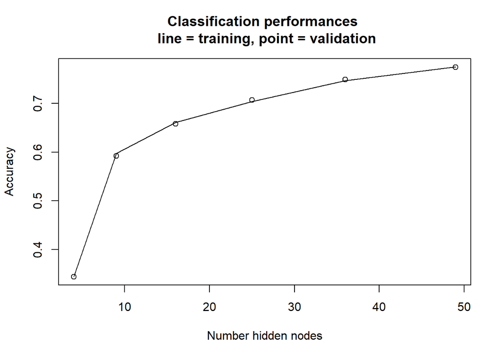

```r
#plotting the results
plot(ns, trainAcc, type = 'l', main = 'Classification performances \n line = training, point = validation', xlab = 'Number hidden nodes', ylab = 'Accuracy')
points(ns, validAcc)
```

```r
#choosing the best network
bestID <- which.max(validAcc)
print(paste0('The best configuration is the number ', bestID, ', corresponding to ', ns[bestID], ' hidden nodes.'))
```

```
## [1] "The best configuration is the number 6, corresponding to 49 hidden nodes."
```

An important consideration on the previous graph: the performance estimates on the training and validation sets are very close to each other. This is not true in general, and usually performances on the validation set are worse than the ones on the training set.

```r
#retrain on the whole train + validation set
bestNn <- mx.mlp(data = training[ , -1],
             label = training[ , 1],
             array.layout = "rowmajor",
             hidden_node = ns[bestID],
             out_node = 10,
             activation = "tanh",
             out_activation = "softmax",
             learning.rate = 0.1,
             num.round = 10,
             verbose = FALSE)

#accuracy on the test set
preds <- predict(bestNn, test[ , -1], array.layout = "rowmajor")
preds <- apply(preds, 2, which.max) - 1
acc <- sum(preds == test[ , 1])/(dim(test)[1])
print(paste0('The accuracy is: ', round(acc, 3)))
```

```
## [1] "The accuracy is: 0.764"
```

```r
#confusion matrix
labels <- test[ , 1];
confusion <- table(preds, labels)
print('Confusion matrix')
```

```
## [1] "Confusion matrix"
```

```r
print(confusion)
```

```
##      labels
## preds    0    1    2    3    4    5    6    7    8    9
##     0  876    0   28   22    4  101   26    8   32   20
##     1    0 1045   78    4    2    3    3    9    7    4
##     2    7   26  570    9   14   14   29    8   32    6
##     3    5   12   62  789   10   57    1   39   34   19
##     4    0   18   28    7  784   18   18   27   14   94
##     5   55    1    6   58   13  455   33    4   43   21
##     6   29    3   70    7   28   20  829    2   14    1
##     7    2    5   14    6   18   10    0  836    4  122
##     8    5   24  167   95   10  201   19   11  774   38
##     9    1    1    9   13   99   13    0   84   20  684
```

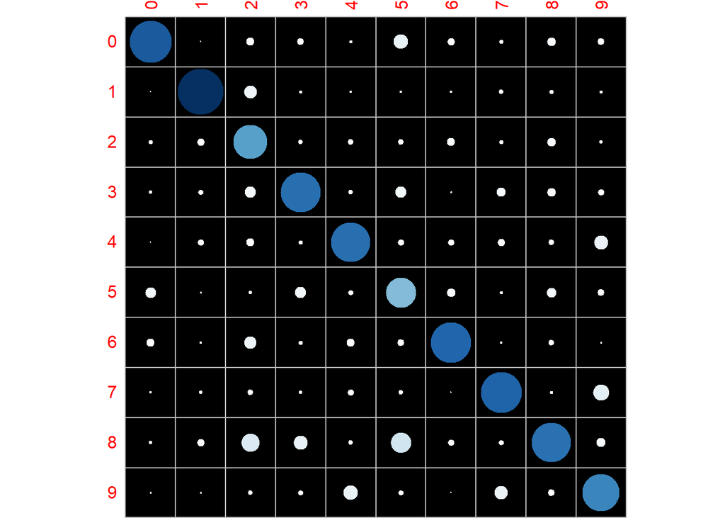

```r
corrplot(corr = confusion, method = 'circle', is.corr = FALSE, bg = 'black', cl.pos = 'n')
```

The performances on the test set further confirm that the chosen configuration has a predictive power (test set accuracy: 0.7642) comparable to the one estimated on the validation set (validation set accuracy: 0.7745833).

### Under the hood of the multilayer perceptron

Let’s analyze the weights of the edges connecting the hidden to the output layer.

```r
#extracting the weights
hoWeights <- as.matrix(bestNn$arg.params[[3]]);
print(dim(hoWeights))
```

```
## [1] 49 10
```

The matrix of weights *hoWeights* contains one column for each output node. This means that the first and second column correspond to the zero and one digit, respectively. Let’s visualize these two vector of weights, by rearranging each of them as a square matrix.

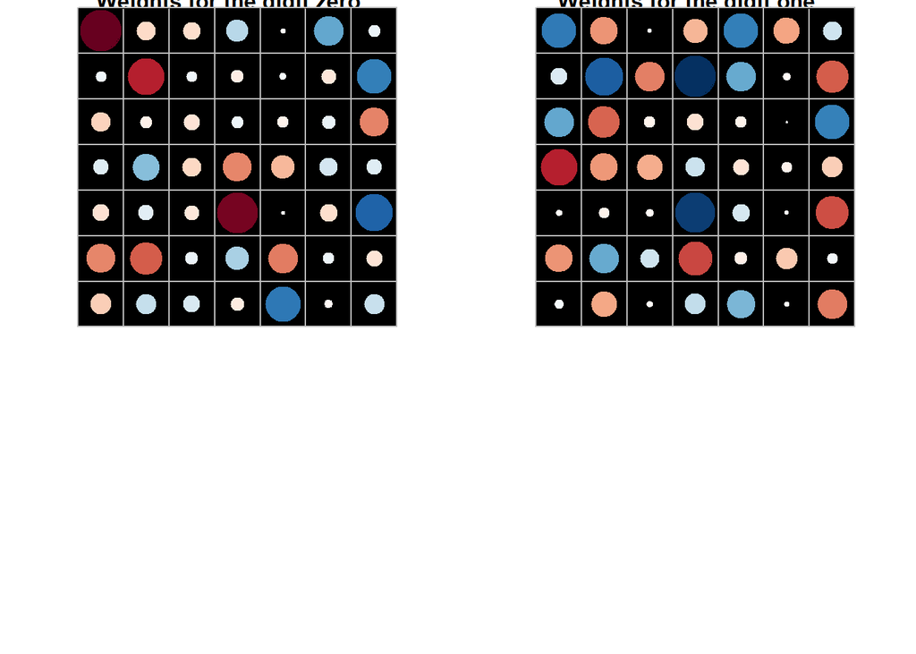

```r
#arranging the plots
par(mfrow=c(2,2))

#plotting the weights for zero
zeroWeights <- matrix(hoWeights[ , 1], sqrt(length(hoWeights[ , 1])), sqrt(length(hoWeights[ , 1])));
corrplot(corr = zeroWeights, method = 'circle', is.corr = FALSE, bg = 'black', title = 'Weights for the digit zero', cl.pos = 'n', tl.pos = 'n')

#plotting the weights for one
oneWeights <- matrix(hoWeights[ , 2], sqrt(length(hoWeights[ , 2])), sqrt(length(hoWeights[ , 2])));
corrplot(corr = oneWeights, method = 'circle', is.corr = FALSE, bg = 'black', title = 'Weights for the digit one', cl.pos = 'n', tl.pos = 'n')
```

Here the left plot refers to the weights of the digit zero, while the right plot to weights the digit one. Red circle correspond to negative values, blue ones to positive values. At a first glance it is evident that some of the weights of the first plot have their sign inverted in the second one. However, it is not easy to understand why the first set of weights allow to identify the digit zero and the second set the digit one. It could be argued that simply re-arranging these weights in a square matrix does not ensure the possibility of gaining any insight. However, interpreting the status of a neural network in a human interpretable way is usually a quite difficult task.

### Decision trees

We will now apply a decision tree algorithm to the MNIST dataset, using the *rpart* function with the default configuration for classification tasks.

```r
#training the tree
set.seed(12345);
tree <- rpart(label ~ ., as.data.frame(training), method = 'class');

#prediction on the test set
preds <- predict(tree, as.data.frame(test[, -1]))
preds <- apply(preds, 1, which.max) - 1
acc <- sum(preds == test[,1])/dim(test)[1]
print(paste0('Accuracy on the test set: ', acc));
```

```
## [1] "Accuracy on the test set: 0.6196"
```

We will forgo optimizing the configuration, and we will focus on the interpretation of the model. The *prp* function of the *rpart.plot* package provides a nice visualization of the tree.

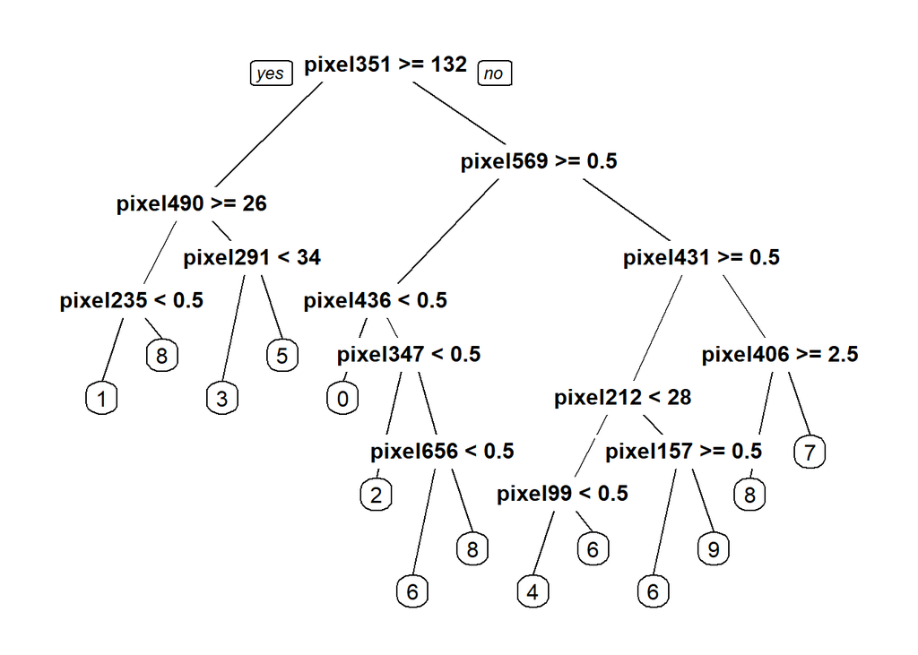

```r
#tree visualization
prp(tree)
```

The tree can be easily interpreted as a set of rules that determine the digits on the basis of the intensity level of a few pixels. In this specific case, the rules can be even applied by hand. Furthermore, only 13 pixels are required for applying the model. This means that decision trees can also work as feature selection methods, indicating which predictors are necessary for solving the problem and which can be discarded. The following image indicate the portions of the 28x28 pixel images that are necessary for classifying digit with the obtained tree.

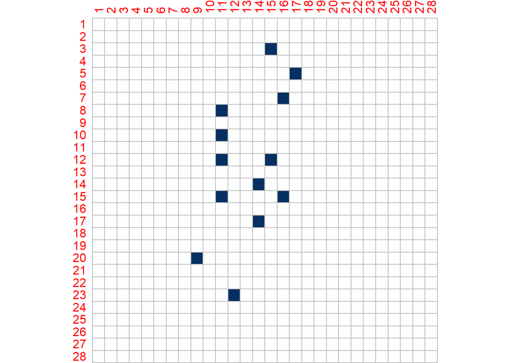

```r
#involved pixels
pixels <- c(351, 490, 235, 291, 569, 436, 347, 656, 431, 212, 99, 157, 406);

#creating the image
pixelsImage <- matrix(0, 28, 28);
for(i in 1:length(pixels)){
  rowId <- floor(pixels[i] / 28);
  colId <- pixels[i] - rowId * 28;
  pixelsImage[rowId, colId] <- 1;
}

#plotting
corrplot(pixelsImage , is.corr = FALSE, method = 'shade', addgrid.col = 'grey', cl.pos = 'n')
```

### Analyzing the Iris dataset

The Iris dataset is one of the most known in the field of statistics and machine learning. First introduced by R. A. Fisher, one of the founder of modern statistics, it can be regarded as the equivalent of “hello word!” of the classification problems. The dataset and its respective description can be found in the University of California Irvine (UCI) Machine Learning Repository (https://archive.ics.uci.edu/ml/datasets/iris).

The goal of the analysis is to discriminate between three types of Iris on the basis of sepal and petal characteristics.

Tasks to perform:

1. load the Iris dataset and create randomly shuffled training, validation and test set;
2. identify the best model with both the *mx.mlp*and *rpart* functions. For *rpart*, consider varying the hyper-parameter *minsplit*, which sets the minimum number of observation that must be present in a node in order to be considered for splitting.
3. Compare the two models: which is the best performing?
4. Comment on the decision tree created by *rpart*; what can you derive from its structure?